# Final Project: an Exploration of the ‘airquality’ Dataset

2025-10-19

# Introduction

‘airquality’ is a built-in data set in R that was compiled from archives of the New York State Department of Conservation and the National Weather Service, which records the daily air quality measurements in New York City from May 1 to September 30, 1973. Besides Day and Month (which are represented by numeric values), there are four main variables of interest: Ozone, Solar.R, Wind, and Temp. Per R documentation, these variable are defined as the following:

- Ozone: Mean ozone in parts per billion from 1300 to 1500 hours at Roosevelt Island
- Solar.R: Solar radiation in Langleys in the frequency band 4000–7700 Angstroms from 0800 to 1200 hours at Central Park
- Wind: Average wind speed in miles per hour at 0700 and 1000 hours at LaGuardia Airport
- Temp: Maximum daily temperature in degrees Fahrenheit at LaGuardia Airport.

With rising temperatures becoming a key concern for many, the scientific motivation behind our inquiry is to better understand how meteorological factors and air quality measurements affect (or simply have a relationship with) daily maximum temperature.

# Outcome

```
## [1] 44
```

```
## [1] 153
```

```
## [1] 111
```

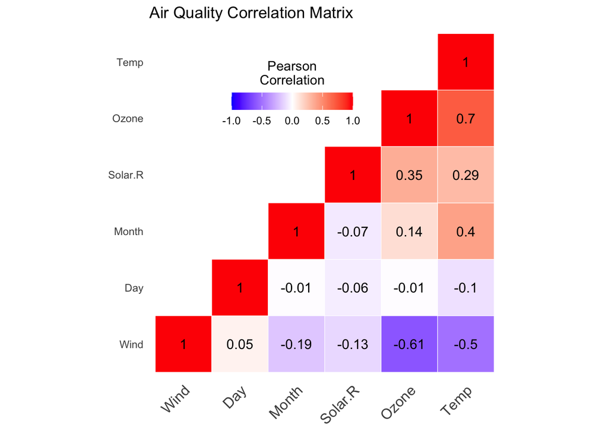

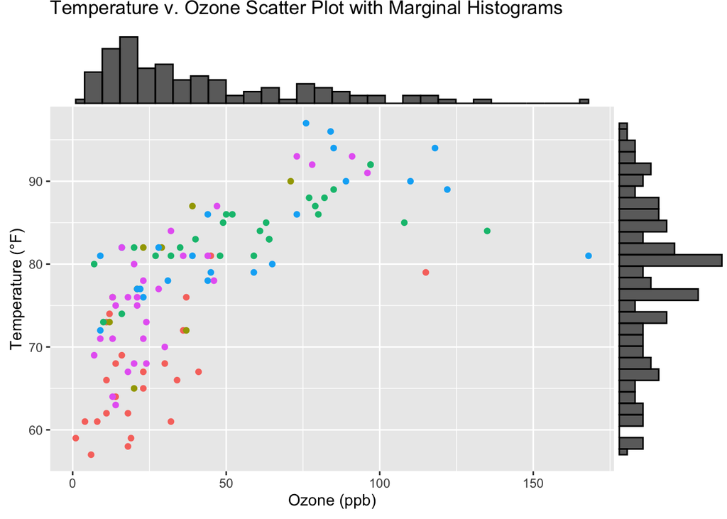

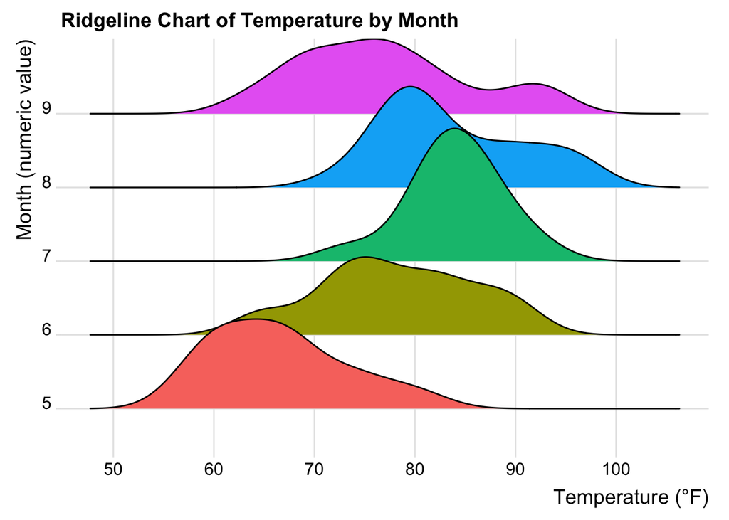

```
##
## Call:
## lm(formula = Temp ~ Ozone + Month, data = new)
##
## Residuals:
##      Min       1Q   Median       3Q      Max
## -21.9545  -4.4396   0.5476   4.6118  12.2303
##
## Coefficients:
##             Estimate Std. Error t value Pr(>|t|)
## (Intercept) 55.41339    2.98090  18.589  < 2e-16 ***
## Ozone        0.18735    0.01799  10.412  < 2e-16 ***
## Month        2.00827    0.40636   4.942 2.84e-06 ***
## ---
## Signif. codes:  0 '***' 0.001 '**' 0.01 '*' 0.05 '.' 0.1 ' ' 1
##
## Residual standard error: 6.215 on 108 degrees of freedom
## Multiple R-squared:  0.5824, Adjusted R-squared:  0.5747
## F-statistic: 75.31 on 2 and 108 DF,  p-value: < 2.2e-16
```

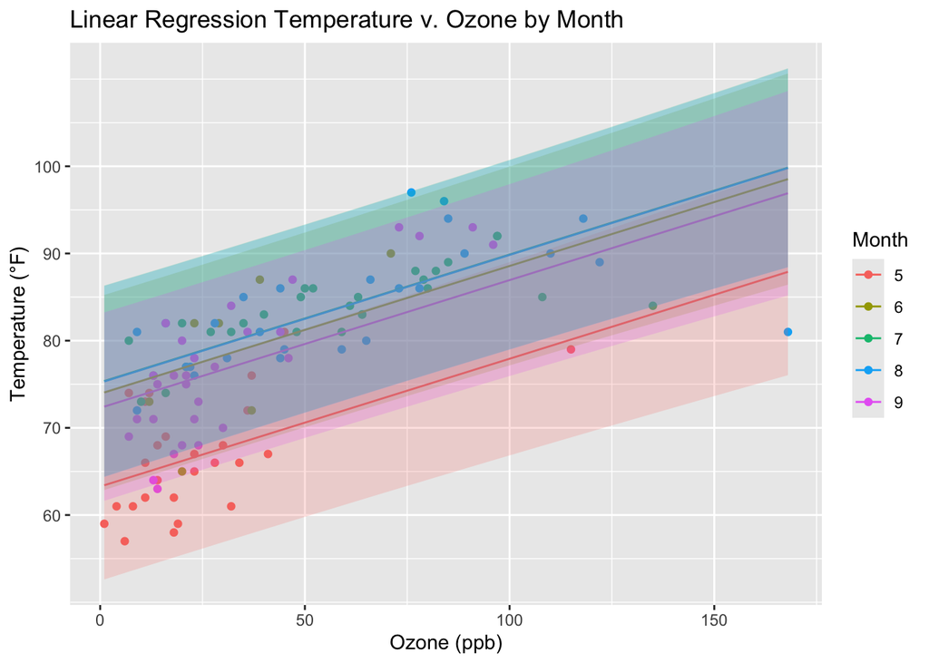

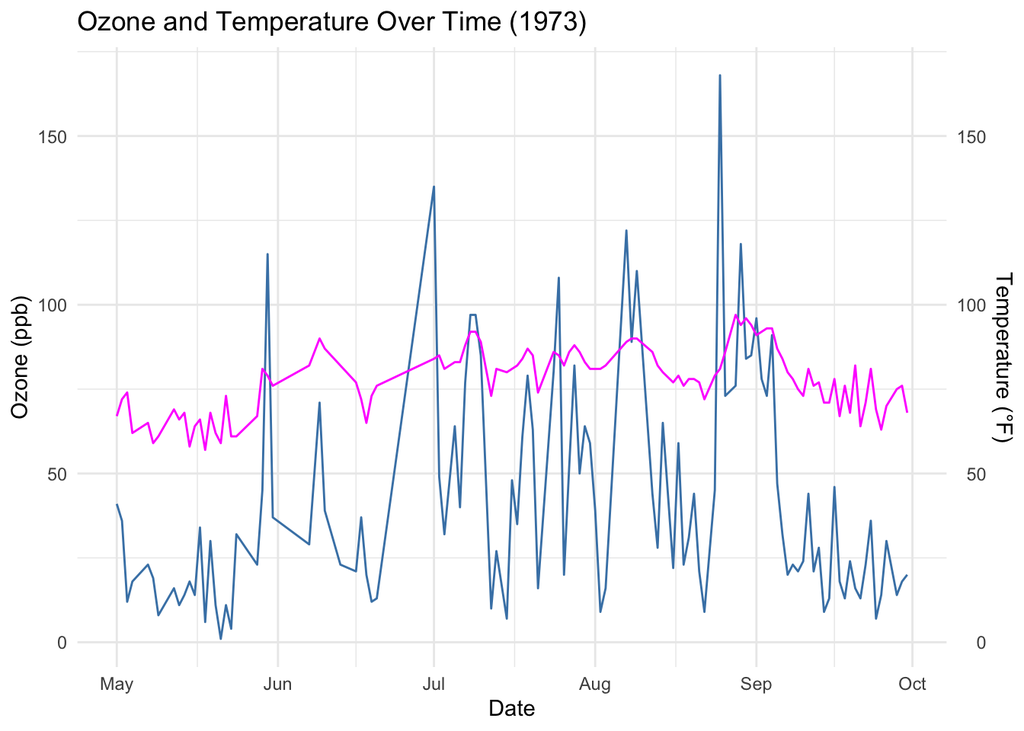

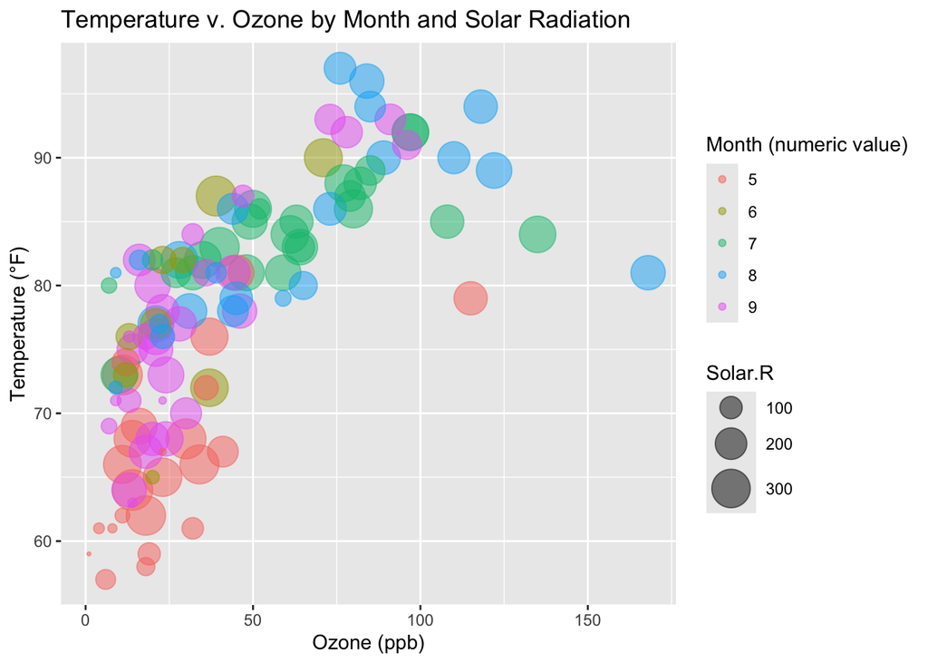

[interactive chart not shown]

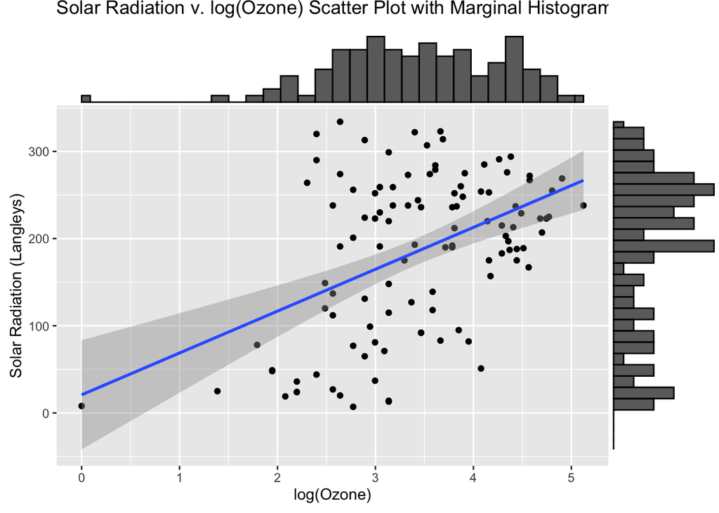

# Discussion

‘airquality’ has 44 NA values. We then eliminated rows with NA values reducing our data set from 153 to 111 rows. From this new data set, the above visualizations were plotted.

In order to explore any potential relationships with our variable of interest, Temperature, we first create a correlation matrix. We find that Ozone has the highest correlation, and thus strongest relationship, with Temperature. With this finding, we then create a scatter plot to explicitly visualize this relationship with each variable’s marginal histograms. The scatter plot hints at Ozone’s positive correlation with Temperature, and our marginal histograms show that Ozone is heavily right skewed while temperature less so.

We, then, plot the linear relationships between Temperature and Ozone, where we find that July and August are hotter than May and June across the Ozone range, and most observed points fall within its ribbons, suggesting the model fits reasonably well. To further illustrate this correlation effect, we plot a times series graph. Temperature and Ozone generally track with each other across time. For example, when there is a spike in Ozone, there is subsequently an increase in Temperature as well.

In addition, we find that both Temperature and Ozone both have a sizeable relationship with Solar Radiation in our correlation matrix. Since higher levels of solar radiation increase the likelihood of forming ground-level ozone, this relationship is expected. Thu, exploring Solar Radiation may aid in our understanding of air quality measurements and their effect on Temperature. We create a bubble plot to help visualize this three-way relationship. However, since there is no noticeable difference in size for an increase across Temperature or Ozone, we decide to better visualize this relationship with a three-dimensional scatter plot of Temperature, Ozone, and Solar Radiation. Visually, we see that there is a weak relationship between Temperature and Solar Radiation. There is, however, a noticeably stronger relationship with Ozone and Solar Radiation. Interestingly, it takes on a funnel shape, so we graph Solar Radiation v. log(Ozone) to see if that strengthens its linear relationship.

In all, through this visual and quantitative exploration of the ‘airquality’ data set in R, we found key factors such as Ozone (ppb) and Solar Radiation (Langley) that may influence Temperature (°F), which could provide key findings toward understanding and predicting the effects of air quality on rising temperatures by encouraging further interest in how to decrease levels of pollutants that contribute toward smog-forming reactions.